# Using GeDi on the macrophage dataset (ERP020977)

Annekathrin Silvia Nedwed

Institute of Medical Biostatistics, Epidemiology and Informatics (IMBEI), Mainz  
anedwed@uni-mainz.de

Arsenij Ustjanzew

Institute of Medical Biostatistics, Epidemiology and Informatics (IMBEI), Mainz

Najla Abassi

Institute of Medical Biostatistics, Epidemiology and Informatics (IMBEI), Mainz

Leon Dammer

Institute of Medical Biostatistics, Epidemiology and Informatics (IMBEI), Mainz

Alicia Schulze

Institute of Medical Biostatistics, Epidemiology and Informatics (IMBEI), Mainz

Sara Salome Helbich

Institute of Immunology, University Medical Center Mainz, Mainz, Germany  
Research Center for Immunotherapy (FZI), Mainz, Germany

Michael Delacher

Institute of Immunology, University Medical Center Mainz, Mainz, Germany  
Research Center for Immunotherapy (FZI), Mainz, Germany

Konstantin Strauch

Institute of Medical Biostatistics, Epidemiology and Informatics (IMBEI), Mainz

Federico Marini

Institute of Medical Biostatistics, Epidemiology and Informatics (IMBEI), Mainz  
Research Center for Immunotherapy (FZI), Mainz, Germany  
Center for Thrombosis and Hemostasis (CTH), Mainz  
marinif@uni-mainz.de

6 November 2025

# 1 About the data

The data illustrated in this document is an RNA-seq dataset, available at the European Nucleotide Archive under the accession code ERP020977 (https://www.ebi.ac.uk/ena/browser/view/ERP020977).

The data is included in the `macrophage` package available on Bioconductor (https://www.bioconductor.org/packages/release/data/experiment/html/macrophage.html). The data was generated as part of the work to identify shared quantitative trait loci (QTLs) for chromatin accessibility and gene expression in human macrophages (Alasoo et al. 2018) - the manuscript is available at https://www.nature.com/articles/s41588-018-0046-7.

# 2 Loading required packages

We load the packages required to perform all the analytic steps presented in this document.

```r
library("DESeq2")
library("clusterProfiler")
library("pcaExplorer")
library("ideal")
library("GeneTonic")
library("apeglm")
library("dplyr")
library("msigdbr")
library("visNetwork")
library("org.Hs.eg.db")
library("GeDi")
library("ggplot2")
library("visNetwork")
library("utils")
library("ComplexHeatmap")
```

# 3 Data processing

Before we can use the data of the `macrophage` package in `GeDi`, we first have to preprocess and analyze the data.

For this, we first obtain the data from the package and generate a `DESeqDataset`. This step is also demonstrated and described in more detail in the package vignette of `GeDi`. The vignette is accessible through `browseVignette(GeDi)` after successfully installing the package. Similar to the the vignette, we will only use and compare the Interferon gamma (IFNg) treated and the naive samples. This comparison and the resulting prepared data for `Gedi` also mirror the example data available in `GeDi`.

```r
# Obtain the data from the macrophage package
data("gse", package = "macrophage")

# Create a DESeqDataset object from the data choosing the line and condition
# of the samples as design.
dds_macrophage <- DESeqDataSet(gse, design = ~line + condition)

# Transform the Gencode identifiers to Ensembl identifiers
rownames(dds_macrophage) <- substr(rownames(dds_macrophage), 1, 15)

# Have a look at the object
dds_macrophage
```

```
## class: DESeqDataSet
## dim: 58294 24
## metadata(7): tximetaInfo quantInfo ... txdbInfo version
## assays(3): counts abundance avgTxLength
## rownames(58294): ENSG00000000003 ENSG00000000005 ... ENSG00000285993
##   ENSG00000285994
## rowData names(2): gene_id SYMBOL
## colnames(24): SAMEA103885102 SAMEA103885347 ... SAMEA103885308
##   SAMEA103884949
## colData names(15): names sample_id ... condition line
```

## 3.1 Differential expression analysis

After we have set up the the `DESeq2` object of the `macrophage` dataset, we can follow the `DESeq2` workflow and determine the differentially expressed genes.

We use a False Discovery Rate of 5% similar to the vignette of `GeDi`.

However, before we perform the DE analysis, we filter for low expressed genes. In this example we filter all genes that do not have at least 10 counts in at least 6 samples (where 6 is the size of the smallest group in the data).

```r
# Filter genes based on read counts
# Calculate the number of genes with at least 10 counts in at least 6 samples
keep <- rowSums(counts(dds_macrophage) >= 10) >= 6

# Subset the DESeqDataSet object to keep only the selected genes
dds_macrophage <- dds_macrophage[keep, ]

# Have a look at the resulting DESeqDataSet object
dds_macrophage
```

```
## class: DESeqDataSet
## dim: 17806 24
## metadata(7): tximetaInfo quantInfo ... txdbInfo version
## assays(3): counts abundance avgTxLength
## rownames(17806): ENSG00000000003 ENSG00000000419 ... ENSG00000285982
##   ENSG00000285994
## rowData names(2): gene_id SYMBOL
## colnames(24): SAMEA103885102 SAMEA103885347 ... SAMEA103885308
##   SAMEA103884949
## colData names(15): names sample_id ... condition line
```

```r
# Set the false discovery rate to 5%
FDR <- 0.05

# Perform the differential gene expression analysis
dds_macrophage <- DESeq(dds_macrophage)
```

After we performed the analysis, we extract the results for the condition IFNg vs naive as we only want to compare the Interferon gamma treated and the naive samples. Afterwards we print a summary overview of the previously extracted results.

In a last step, we add the gene symbols to the resulting `DataFrame` which will later serve as our Genes column in the input data to `GeDi`.

```r
# Extract differentially expressed genes
# Perform contrast analysis comparing "IFNg" condition to "naive" condition
# Set a log2 fold change threshold of 1 and a significance level (alpha) of 0.05
res_macrophage_IFNg_vs_naive <- results(dds_macrophage,
  contrast = c("condition", "IFNg", "naive"),
  lfcThreshold = 1, alpha = 0.05
)

# Print a summary overview of the results
summary(res_macrophage_IFNg_vs_naive)
```

```
##
## out of 17806 with nonzero total read count
## adjusted p-value < 0.05
## LFC > 1.00 (up)    : 652, 3.7%
## LFC < -1.00 (down) : 372, 2.1%
## outliers [1]       : 0, 0%
## low counts [2]     : 0, 0%
## (mean count < 3)
## [1] see 'cooksCutoff' argument of ?results
## [2] see 'independentFiltering' argument of ?results
```

```r
# Add gene symbols to the results in a column "SYMBOL"
res_macrophage_IFNg_vs_naive$SYMBOL <- rowData(dds_macrophage)$SYMBOL
```

## 3.2 Functional enrichment analysis

```r
# Determine the set of background genes as all genes expressed in the dataset
geneUniverseExpr <- rowData(dds_macrophage)$SYMBOL[rowSums(counts(dds_macrophage)) > 0]

# Extract gene symbols from the DESeq2 results object where FDR is below 0.05
# The function deseqresult2df is used to convert the DESeq2 results to a
# dataframe format
# FDR is set to 0.05 to filter significant results
de_symbols_IFNg_vs_naive <- deseqresult2df(res_macrophage_IFNg_vs_naive, FDR = 0.05)$SYMBOL

# Perform Gene Ontology enrichment analysis using the enrichGO function from
# the "clusterProfiler" package
clusterProfiler_IFNg_vs_naive <- enrichGO(
      gene = de_symbols_IFNg_vs_naive,
      universe      = geneUniverseExpr,
      keyType       = "SYMBOL",
      OrgDb         = org.Hs.eg.db,
      ont           = "BP",
      pAdjustMethod = "BH",
      pvalueCutoff  = 0.01,
      qvalueCutoff  = 0.05,
      readable      = FALSE
    )
```

## 3.3 Preparing the data for GeDi

After we have performed the functional enrichment analysis, the data is almost ready to be used with `GeDi`. However, in its current state the data is not yet in the correct format expected by `GeDi`. `GeDi` expects the data to have at least two columns, one named Genesets containing some form of geneset identifiers and one named Genes containing a list of genes belonging to the genesets. While this is not strictly necessary to use `GeDi` on the data, it facilitates the use of the app as the app can be used straight away instead of having to wait for the data to be reformatted. The correct data format is however necessary, if you want to use the data as a parameter as in `GeDi(clusterProfiler_IFNg_vs_naive)`.

For this, we have specifically implemented a function called `path_to_GeDi()` in the package. This function can be used to transform the output of several different enrichment packages, such as `topGO`, `clusterProfiler`, `ReactomePA`, `enrichR` and `fgsea`, to fit the expected input in `GeDi`. Below you can see how to use the function.

Additionally, as full dataset contains roughly 4600 gene sets, which is appropriate for real analyses but unnecessarily large for demonstration purposes, we truncated the data to the first 500 gene sets.

```r
# We're preparing the data for GeDi using the 'path_to_GeDi' function from the package.

macrophage_example <- path_to_GeDi(clusterProfiler_IFNg_vs_naive,
                                   enrichment_package = "clusterProfiler")

macrophage_example <- macrophage_example[1:500, ]
```

After we have preprocessed the data, the data is now ready to be used in `GeDi`.

# 4 Running `GeDi` on the dataset

Now we can start to explore our data using `GeDi`. For this you can either follow the chunks in this document to prepare the data or we can load the prepared object provided with the repository of this document [Github](https://github.com/AnnekathrinSilvia/GeDi_supplement) .

```r
macrophage_example <- readRDS("usecase_macrophage_example.RDS")
```

Once we have loaded the data, we can start the app and interactively explore the data set using:

```r
GeDi(genesets = macrophage_example)
```

Once the app is started, you can have interactive guidance of the user interface and its features by using the introductory tours of each panel of the app.

## 4.1 Using `GeDi`’s functions in analysis reports

The functionality of `GeDi` can be used also as standalone functions, to be called for example in existing analysis reports in RMarkdown, or R scripts.  
In the following chunks, we show how it is possible to call some of the functions on the dataset of the `macrophage` package.

First, we will calculate the distance scores for our data. For this, we will use the Jaccard-Score to demonstrate how distance scores can be calculated. Before these score can be calculated, we have to prepare the data using the `prepareGenesetData()`function - something which is usually done internally in the app, when using `GeDi`.

```r
genes <- GeDi::prepareGenesetData(macrophage_example)

jaccard_score <- GeDi::getJaccardMatrix(genesets = genes)

rownames(jaccard_score) <- colnames(jaccard_score) <- macrophage_example$Genesets
```

Afterwards, we can use the distance scores to generate some plots of the calculated scores, such as a heatmap or a network.

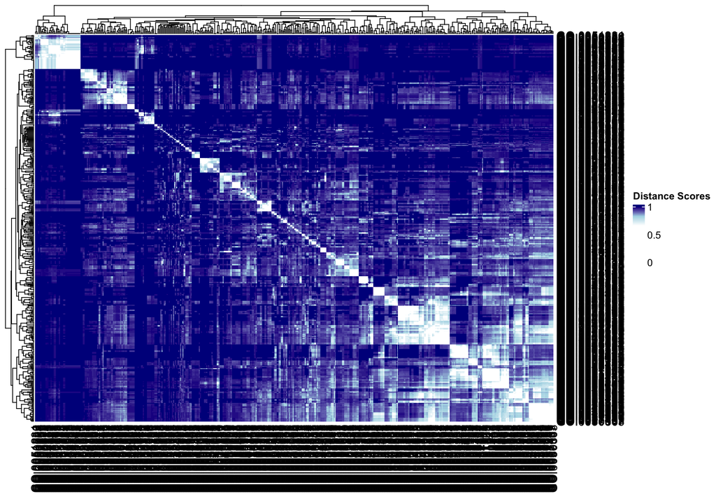

```r
GeDi::distanceHeatmap(jaccard_score)
```

```r
graph <- GeDi::buildGraph(GeDi::getAdjacencyMatrix(jaccard_score, cutOff = 0.3))

visNetwork::visIgraph(graph) %>%
          visNodes(color = list(
            background = "#0092AC",
            highlight = "gold",
            hover = "gold"
          )) %>%
          visEdges(color = list(
            background = "#0092AC",
            highlight = "gold",
            hover = "gold"
          )) %>%
          visOptions(
            highlightNearest = list(
              enabled = TRUE,
              degree = 1,
              hover = TRUE
            ),
            nodesIdSelection = TRUE
          ) %>%
          visExport(
            name = "distance_scores_network",
            type = "png",
            label = "Save Distance Scores graph"
          )
```

[interactive chart not shown]

Once distance scores are calculated, `GeDi`can be used to cluster the genesets based on their calculated pairwise similarity scores. In this example, we will use the Louvain clustering algorithm for this. Afterwards, we use `GeDi`’s visualisation options to visualise the clustering results.

```r
louvain_clustering <- GeDi::louvainClustering(jaccard_score, threshold = 0.3)
```

```r
graph <- GeDi::buildClusterGraph(louvain_clustering,
                                 macrophage_example,
                                 macrophage_example$Genesets,
                                 color_by = "Cluster",
                                 gs_names = macrophage_example$Term)

visNetwork::visIgraph(graph) %>%
          visOptions(
            highlightNearest = list(
              enabled = TRUE,
              degree = 1,
              hover = TRUE
            ),
            nodesIdSelection = TRUE,
            selectedBy = list(variable = "cluster", multiple = TRUE)
          ) %>%
          visExport(
            name = "cluster_network",
            type = "png",
            label = "Save Cluster graph"
          )
```

[interactive chart not shown]

```r
# Plot an enrichment wordcloud for the first cluster
GeDi::enrichmentWordcloud(macrophage_example[louvain_clustering[[1]],])
```

[interactive chart not shown]

# Bibliography

Alasoo, Kaur, Julia Rodrigues, Subhankar Mukhopadhyay, Andrew J Knights, Alice L Mann, Kousik Kundu, Christine Hale, Gordon Dougan, and Daniel J Gaffney. 2018. “Shared genetic effects on chromatin and gene expression indicate a role for enhancer priming in immune response.” *Nature Genetics* 50 (3): 424–31. https://doi.org/10.1038/s41588-018-0046-7.